# Customer churn prediction in the telecommunication sector using a rough set approach - ScienceDirect

### 6.4. Approximation analysis

We have also analyzed the vagueness in the dataset by using upper approximation and lower approximation of RST described in Table 9. Based on the results of approximation analysis, it is observed that there is no vagueness in the samples.

Table 9. Approximation Analysis.

| Decision class | No. of objects | Lower approximation | Upper approximation | Accuracy |
| --- | --- | --- | --- | --- |
| NC | 2850 | 2850 | 2850 | 1.000 |
| C | 483 | 483 | 483 | 1.000 |

### 6.5. Comparison and discussion of simulation results

In this study, the proposed approach evaluated four well-known rules-generation algorithms (discussed in subsection 3.5) based on RST, to mine concise rules for efficiently predicting customer churns. The total number of rules induced from the telecom sector by applying rules-generation algorithms are summarized in Table 6. The LEM2 algorithm is seen to perform well on symbolic attributes only [75]. Fig. 6 reflects the graphical depiction of the induced concise rules.

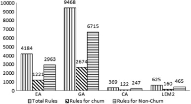

Fig. 6. Summary of total rules induced by each rule generation algorithm where vertical-line bars represent the total number of rules induced, diagonals-line bars reflect the total number of rules induced for classifying churns, and finally, the horizontal line bar illustrates the total number of rules induced for classifying non-churns objects.

It is observed that by applying both CA and LA in the proposed approach for rule generation, tend to produce a lesser number of rules than GA and EA. Specifically, the CA and LA both produced fewer rules (i.e., 369, and 625 respectively), as opposed to the total number of decision rules (4184 and 9468) generated by EA and GA respectively.

In the proposed study, EA could not achieve optimal results as compared to GA, since the EA with RST was found to be relatively ineffective in reducing large data in the decision table (information system) for producing effective decision rules. On the other hand, GA begins by evaluating the problem as a population of solution candidates and generates new offspring through a cross-over and mutation process, with the aim of having the best-fit candidate when the next step for evaluation starts and so on [78]. It is concluded that a classifier trained on a large decision table using RST classification, coupled with the GA for inducing efficient decision rules, can produce the optimal solution for CCPin the telecommunication sector, subject to optimizing parameter settings (see Table 5). More importantly, the proposed approach is also flexible in evolving itself to a new situation following a new generation, since background knowledge is not really required about the dataset [79].

Finally, it is clear from the comparative results, that the proposed approach performed very well as compared to previously applied techniques on the same benchmark dataset from the telecommunication industry (see Table 10).

Table 10. Comparison of [predictive performance](https://www.sciencedirect.com/topics/computer-science/predictive-performance) of proposed & previous approaches applied to the same dataset.

| **Techniques** | **Recall** | **Precision** | **Misclassification** | **Accuracy** | **F-Measure** |
| --- | --- | --- | --- | --- | --- |
| [2] | 81.75 | 66.27 | 6.76 | 93.2 | 73.2 |
| [41] | 76.47 | 80.60 | 22.10 | 77.9 | 78.5 |
| [41] | 83.90 | 83.40 | 16.30 | 83.7 | 83.7 |
| [41] | 83.37 | 84.20 | 16.30 | 83.7 | 83.8 |
| [39] | 52.12 | 81.90 | 14.37 | 85.6 | 63.7 |
| [39] | 39.15 | 79.05 | 22.14 | 77.9 | 52.4 |
| [39] | 59.44 | 80.95 | 11.44 | 88.6 | 68.5 |
| [46] | 30.49 | 71.43 | 29.47 | 70.5 | 42.7 |
| [46] | 78.45 | 91.72 | 3.15 | 96.85 | 84.6 |
| Proposed | **86.0** | **100** | **1.90** | **98.1** | **92.5** |

## 7. Conclusion and future work

In this study, the application of RST is explored to predict customer churn in the [telecommunication sector](https://www.sciencedirect.com/topics/computer-science/telecommunication-sector) by constructing a predictive classifier that can forecast churn behavior based on accumulated knowledge. To evaluate the results of the proposed approach, a benchmarking study is applied and the performance of four different rules-generation algorithms (EA, GA, CA and LA) is investigated. It is found that RST classification based on GA outperforms other rules-generation algorithms in terms of precision, recall, the rate of misclassification, lift, coverage, accuracy, and F-measure. The discretization process applied to different attributes revealed some important insights regarding reasons for customer churn that can ultimately help the decision makers to develop retention policies accordingly. The proposed approach also outperforms other techniques applied on the same dataset in terms of precision, recall, accuracy, F-measure and rate of misclassification. It is important to note that the study conducted is pertaining to the specific dataset used for this study; results may vary with other datasets.

This study has shed some light on the performance of popular ML techniques for the CCP issues, and supported the advantage of RST application in the proposed approach. In future, we intend to further theoretically and experimentally investigate the proposed approach while considering several other pertinent issues. Firstly, churn datasets exhibit the class imbalance problem; whereby, the churn class (minority class or class of interest) contains fewer number of samples as compared to the non-churn class (majority class). This makes it difficult to recognize the minority class for some ML techniques; although they may achieve high overall accuracy. Secondly, eliminating and detecting of outliers would greatly contribute to providing better results. Finally, in this study the profiles of predicted customer churns were not considered; while these might be of interest to organizations in decision making related to retention of specific churn customers or letting them go. Thus worthy churn customers, at focus, could possibly have greater lifetime value. Hence, we wish to address these challenging issues in future research.

## Acknowledgements

The authors are grateful to the anonymous reviewers for their insightful comments and suggestions, which helped improve the quality of this paper. Professor A. Hussain is supported by the UK Engineering and Physical Sciences Research Council (EPSRC) grant no. EP/M026981/1.

## References

**[1]**

J. Hadden, A. Tiwari, R. Roy, D. Ruta**Computer assisted customer churn management: state-of-the-art and future trends**

Comput. Oper. Res., 34 (10) (2007), pp. 2902-2917

[Article](https://www.sciencedirect.com/science/article/pii/S0305054805003503)[Download PDF](https://www.sciencedirect.com/science/article/pii/S0305054805003503/pdfft?md5=f557e310adf73dfeaa4b7d30a6c4f4ef&pid=1-s2.0-S0305054805003503-main.pdf)[View Record in Scopus](https://www.scopus.com/inward/record.url?eid=2-s2.0-33847659604&partnerID=10&rel=R3.0.0)Google Scholar

**[2]**

A. Sharma, P. Prabin Kumar**A neural network based approach for Predicting Customer churn in cellular network services**

Int. J. Comput. Appl., 27 (11) (2011), pp. 26-31

[CrossRef](https://doi.org/10.5120/3344-4605)[View Record in Scopus](https://www.scopus.com/inward/record.url?eid=2-s2.0-84875108096&partnerID=10&rel=R3.0.0)Google Scholar

**[3]**

W. Verbeke, D. Martens, C. Mues, B. Baesens**Building comprehensible customer churn prediction models with advanced rule induction techniques**

Expert Syst. Appl., 38 (3) (2011), pp. 2354-2364

[Article](https://www.sciencedirect.com/science/article/pii/S0957417410008067)[Download PDF](https://www.sciencedirect.com/science/article/pii/S0957417410008067/pdfft?md5=8f822ad3f57421357b364a44cd122b30&pid=1-s2.0-S0957417410008067-main.pdf)[View Record in Scopus](https://www.scopus.com/inward/record.url?eid=2-s2.0-78049530278&partnerID=10&rel=R3.0.0)Google Scholar

**[4]**

C. Kirui, L. Hong, W. Cheruiyot, H. Kirui**Predicting customer churn in mobile telephony industry using probabilistic classifiers in data mining**

IJCSI Int. J. Comput. Sci. Issues, 10 (2) (2013), pp. 165-172

[View Record in Scopus](https://www.scopus.com/inward/record.url?eid=2-s2.0-84914109809&partnerID=10&rel=R3.0.0)Google Scholar

**[5]**

B. Huang, M.T. Kechadi, B. Buckley**Customer churn prediction in telecommunications**

Expert Syst. Appl., 39 (1) (2012), pp. 1414-1425

[Article](https://www.sciencedirect.com/science/article/pii/S0957417411011353)[Download PDF](https://www.sciencedirect.com/science/article/pii/S0957417411011353/pdfft?md5=eb8ad9e8dd75f739841339618bb9ac14&pid=1-s2.0-S0957417411011353-main.pdf)[View Record in Scopus](https://www.scopus.com/inward/record.url?eid=2-s2.0-81855164826&partnerID=10&rel=R3.0.0)[Google Scholar](https://scholar.google.com/scholar_lookup?title=Customer%20churn%20prediction%20in%20telecommunications&publication_year=2012&author=B.%20Huang&author=M.T.%20Kechadi&author=B.%20Buckley)

**[6]**

C.-S. Lin, G.-H. Tzeng, Y.-C. Chin**Combined rough set theory and flow network graph to predict customer churn in credit card accounts**

Expert Syst. Appl., 38 (1) (2011), pp. 8-15

[Article](https://www.sciencedirect.com/science/article/pii/S0957417410004501)[Download PDF](https://www.sciencedirect.com/science/article/pii/S0957417410004501/pdfft?md5=64424a6b91b4aed510f8ed34ff6ec1e5&pid=1-s2.0-S0957417410004501-main.pdf)[CrossRef](https://doi.org/10.1615/ichmt.2011.tmnn-2011.390)[View Record in Scopus](https://www.scopus.com/inward/record.url?eid=2-s2.0-77956612708&partnerID=10&rel=R3.0.0)Google Scholar

**[7]**

R.H. Wolniewicz, R. Dodier**Predicting customer behavior in telecommunications**

IEEE Intell. Syst., 19 (2) (2004), pp. 50-58

[Google Scholar](https://scholar.google.com/scholar_lookup?title=Predicting%20customer%20behavior%20in%20telecommunications&publication_year=2004&author=R.H.%20Wolniewicz&author=R.%20Dodier)

**[8]**

A. Idris, A. Khan, Y. Soo**Intelligent churn prediction in telecom: employing mRMR feature selection and RotBoost based ensemble classification**

Springer Science Business Media, New York (2013), pp. 659-672

[CrossRef](https://doi.org/10.1007/s10489-013-0440-x)[View Record in Scopus](https://www.scopus.com/inward/record.url?eid=2-s2.0-84884292459&partnerID=10&rel=R3.0.0)Google Scholar

**[9]**

Z. Pawlak**Rough sets**

Int. J. Comput. Inf. Sci., 11 (5) (1982), pp. 341-356

[CrossRef](https://doi.org/10.1007/BF01001956)[View Record in Scopus](https://www.scopus.com/inward/record.url?eid=2-s2.0-27744565978&partnerID=10&rel=R3.0.0)[Google Scholar](https://scholar.google.com/scholar_lookup?title=Rough%20sets&publication_year=1982&author=Z.%20Pawlak)

**[10]**

S.-Y. Hung, D.C. Yen, H.-Y. Wang**Applying data mining to telecom churn management**

Expert Syst. Appl., 31 (3) (2006), pp. 515-524

[Article](https://www.sciencedirect.com/science/article/pii/S0957417405002654)[Download PDF](https://www.sciencedirect.com/science/article/pii/S0957417405002654/pdfft?md5=77918bff8d12636d8f6b9c98f4f059c6&pid=1-s2.0-S0957417405002654-main.pdf)[View Record in Scopus](https://www.scopus.com/inward/record.url?eid=2-s2.0-33744831465&partnerID=10&rel=R3.0.0)[Google Scholar](https://scholar.google.com/scholar_lookup?title=Applying%20data%20mining%20to%20telecom%20churn%20management&publication_year=2006&author=S.-Y.%20Hung&author=D.C.%20Yen&author=H.-Y.%20Wang)

**[11]**

C.-P. Wei, I.-T. Chiu**Turning telecommunications call details to churn prediction: a data mining approach**

Expert Syst. Appl., 23 (2) (2002), pp. 103-112

[Article](https://www.sciencedirect.com/science/article/pii/S0957417402000301)[Download PDF](https://www.sciencedirect.com/science/article/pii/S0957417402000301/pdfft?md5=0d0c4c5bd71968bc2b17f1cec48b6328&pid=1-s2.0-S0957417402000301-main.pdf)[View Record in Scopus](https://www.scopus.com/inward/record.url?eid=2-s2.0-0036696364&partnerID=10&rel=R3.0.0)Google Scholar

**[12]**

V.V. Saradhi, G.K. Palshikar**Employee churn prediction**

(Mar.)

Expert Syst. Appl., 38 (3) (2011), pp. 1999-2006

(Mar.)

[Article](https://www.sciencedirect.com/science/article/pii/S0957417410007621)[Download PDF](https://www.sciencedirect.com/science/article/pii/S0957417410007621/pdfft?md5=7ba55bfbebd1af297db284c6cb662ce3&pid=1-s2.0-S0957417410007621-main.pdf)[View Record in Scopus](https://www.scopus.com/inward/record.url?eid=2-s2.0-78049527239&partnerID=10&rel=R3.0.0)[Google Scholar](https://scholar.google.com/scholar_lookup?title=Employee%20churn%20prediction&publication_year=2011&author=V.V.%20Saradhi&author=G.K.%20Palshikar)

**[13]**

V. Lazarov, M. Capota**churn prediction**

Bus. Anal. Course TUM Comput. Sci. (2007)

[Google Scholar](https://scholar.google.com/scholar_lookup?title=churn%20prediction&publication_year=2007&author=V.%20Lazarov&author=M.%20Capota)

**[14]**

L.Backstrom, D.Huttenlocher, J.Kleinberg, X.Lan, Group formation in large social networks, in: Proceedings of the 12th ACM SIGKDD international conference on Knowledge discovery and data mining - KDD ’06pp. 44–54, 2006.

Google Scholar

**[15]**

L.Xi, Y.Wenjing, L.An, N.Haiying, H.Lixian, Q.Luo, C.Yan, Churn Analysis of Online Social Network Users Using Data Mining Techniques, Preced. International multi Conference Eng. Comput. Sci., no. 1, pp. 14–16, 2012.

Google Scholar

**[16]**

W. Verbeke, D. Martens, B. Baesens**Social network analysis for customer churn prediction**

Appl. Soft Comput., 14 (2014), pp. 431-446

[Article](https://www.sciencedirect.com/science/article/pii/S1568494613003116)[Download PDF](https://www.sciencedirect.com/science/article/pii/S1568494613003116/pdfft?md5=2d77e3df2d0741d76928c57846e05f95&pid=1-s2.0-S1568494613003116-main.pdf)[View Record in Scopus](https://www.scopus.com/inward/record.url?eid=2-s2.0-84889092660&partnerID=10&rel=R3.0.0)[Google Scholar](https://scholar.google.com/scholar_lookup?title=Social%20network%20analysis%20for%20customer%20churn%20prediction&publication_year=2014&author=W.%20Verbeke&author=D.%20Martens&author=B.%20Baesens)

**[17]**

D.Archambault, N.Hurley, C.T.Tu, ChurnVis: Visualizing mobile telecommunications churn on a social network with attributes,Adv. Soc. Networks Anal. Min. (ASONAM), 2013 IEEE/ACM, pp. 894–901, 2013.

Google Scholar

**[18]**

K.Dasgupta, R.Singh, B.Viswanathan, D.Chakraborty, S.Mukherjea, A.A.Nanavati, A.Joshi, Social ties and their relevance to churn in mobile telecom networks, in: Proceedings of the 11th international conference on Extending database technology Advances in database technology - EDBT ’08, pp. 668–677, 2008.

Google Scholar

**[19]**

J. David Nunez-Gonzalez, M. Grana, B. Apolloni**Reputation features for trust prediction in social networks**

Neurocomputing, 166 (2014), pp. 1-7

Google Scholar

**[20]**

U. Prasad Devi, S. Madhavi**Prediction Of churn behavior Of Bank customers**

Bus. Intell. J., 5 (1) (2012), pp. 96-101

[Google Scholar](https://scholar.google.com/scholar_lookup?title=Prediction%20Of%20churn%20behavior%20Of%20Bank%20customers&publication_year=2012&author=U.%20Prasad%20Devi&author=S.%20Madhavi)

**[21]**

K.Chitra, B.Subashini, Customer Retention in Banking Sector using Predictive Data Mining Technique, ICIT 2011 5th International Conference Inf. Technol., 2011.

Google Scholar

**[22]**

J. Bloemer, K. de Ruyter, P. Peeters**Investigating drivers of bank loyalty: the complex relationship between image, service quality and satisfaction**

Int. J. Bank Mark., no. 16 (1998), pp. 276-286

[View Record in Scopus](https://www.scopus.com/inward/record.url?eid=2-s2.0-84986155804&partnerID=10&rel=R3.0.0)Google Scholar

**[23]**

N. Nguyen, G. LeBlanc**The mediating role of corporate image on customers’ retention decisions: an investigation in financial services**

Int. J. Bank Mark., 16 (2) (1998), pp. 52-65

[View Record in Scopus](https://www.scopus.com/inward/record.url?eid=2-s2.0-84887051004&partnerID=10&rel=R3.0.0)[Google Scholar](https://scholar.google.com/scholar?q=The%20mediating%20role%20of%20corporate%20image%20on%20customers%20retention%20decisions:%20an%20investigation%20in%20financial%20services)

**[24]**

A. Zakaryazad, E. Duman**A profit-driven artificial neural network (ANN) with applications to fraud detection and direct marketing**

Neurocomputing, 175 (2016), pp. 121-131

[Article](https://www.sciencedirect.com/science/article/pii/S0925231215015015)[Download PDF](https://www.sciencedirect.com/science/article/pii/S0925231215015015/pdfft?md5=332e9648f29db5aa2d81b3a09804727c&pid=1-s2.0-S0925231215015015-main.pdf)[View Record in Scopus](https://www.scopus.com/inward/record.url?eid=2-s2.0-84964444611&partnerID=10&rel=R3.0.0)[Google Scholar](https://scholar.google.com/scholar?q=A%20profit-driven%20artificial%20neural%20network%20%20with%20applications%20to%20fraud%20detection%20and%20direct%20marketing)

**[25]**

K.C. Lee, N. Chung, K. Shin**An artificial intelligence-based data mining approach to extracting strategies for reducing the churning rate in credit card industry**

J. Intell. Inf. Syst., 8 (2) (2002), pp. 15-35

[View Record in Scopus](https://www.scopus.com/inward/record.url?eid=2-s2.0-26844535252&partnerID=10&rel=R3.0.0)Google Scholar

**[26]**

D. Van den Poel, B. Larivière**Customer attrition analysis for financial services using proportional hazard models**

Eur. J. Oper. Res., 157 (1) (2004), pp. 196-217

[Article](https://www.sciencedirect.com/science/article/pii/S0377221703000699)[Download PDF](https://www.sciencedirect.com/science/article/pii/S0377221703000699/pdfft?md5=5e69b309c63d6a81e82c930d84c6792e&pid=1-s2.0-S0377221703000699-main.pdf)[View Record in Scopus](https://www.scopus.com/inward/record.url?eid=2-s2.0-1842478892&partnerID=10&rel=R3.0.0)Google Scholar

**[27]**

J.Kawale, A.Pal, J.Srivastava, Churn Prediction in MMORPGs: A Social Influence Based Approach, in: Proceedings 2009 International Conference Comput. Sci. Eng., vol. 4, pp. 423–428, 2009.

Google Scholar

**[28]**

M.Suznjevic, I.Stupar, M.Matijasevic, MMORPG Player Behavior Model based on Player Action Categories, in: Proceedings 10th Annu. Work. Netw. Syst. Support Games. IEEE Press, 2011.

Google Scholar

**[29]**

K.Chen, C.Lei, Network game design: Hints and implications of player interaction, in: Proceedings 5th ACM SIGCOMM Work. Netw. Syst. Support games., pp. 1–9, 2006.

Google Scholar

**[30]**

S. Meaghan, B. Nick**Voluntary turnover: knowledge management**

J. Intellect. Cap., 3 (3) (2002), pp. 303-322

[Google Scholar](https://scholar.google.com/scholar_lookup?title=Voluntary%20turnover%3A%20knowledge%20management&publication_year=2002&author=S.%20Meaghan&author=B.%20Nick)

**[31]**

M.Kane, Laura, Predictive Models of Employee Voluntary Turnover, 2007.

[Google Scholar](https://scholar.google.com/scholar?q=M.Kane,%20Laura,%20Predictive%20Models%20of%20Employee%20Voluntary%20Turnover,%C2%A02007.)

**[32]**

J. Burez, D. Van den Poel**CRM at a pay-TV company: using analytical models to reduce customer attrition by targeted marketing for subscription services**

Expert Syst. Appl., 32 (2) (2007), pp. 277-288

[Article](https://www.sciencedirect.com/science/article/pii/S0957417405003374)[Download PDF](https://www.sciencedirect.com/science/article/pii/S0957417405003374/pdfft?md5=5c73eeb2a3eb9bf9948ff5f28908d0d0&pid=1-s2.0-S0957417405003374-main.pdf)[View Record in Scopus](https://www.scopus.com/inward/record.url?eid=2-s2.0-33750429921&partnerID=10&rel=R3.0.0)Google Scholar

**[33]**

K. Coussement, D. Van den Poel**Churn prediction in subscription services: an application of support vector machines while comparing two parameter-selection techniques**

Expert Syst. Appl., 34 (1) (2008), pp. 313-327

[Article](https://www.sciencedirect.com/science/article/pii/S0957417406002806)[Download PDF](https://www.sciencedirect.com/science/article/pii/S0957417406002806/pdfft?md5=942186048f1b9a6aa536115088302e29&pid=1-s2.0-S0957417406002806-main.pdf)[View Record in Scopus](https://www.scopus.com/inward/record.url?eid=2-s2.0-34248524002&partnerID=10&rel=R3.0.0)Google Scholar

**[34]**

G.Dror, D.Pelleg, O.Rokhlenko, I.Szpektor, Churn prediction in new users of Yahoo! answers, in: Proceedings of the 21st International Conference companion World Wide Web - WWW ’12 Companion, pp. 829–834, 2012.

Google Scholar

**[35]**

R.A. Soeini, K.V. Rodpysh**Applying data mining to insurance Customer churn management**

Int. Proc. Comput. Sci. Inf. Technol., 30 (2012), pp. 82-92

[View Record in Scopus](https://www.scopus.com/inward/record.url?eid=2-s2.0-84914176990&partnerID=10&rel=R3.0.0)[Google Scholar](https://scholar.google.com/scholar_lookup?title=Applying%20data%20mining%20to%20insurance%20Customer%20churn%20management&publication_year=2012&author=R.A.%20Soeini&author=K.V.%20Rodpysh)

**[36]**

C. Rygielski, J.-C. Wang, C.D. Yen**Data mining techniques for customer relationship management**

Technol. Soc., 24 (4) (2002), pp. 483-502

[Article](https://www.sciencedirect.com/science/article/pii/S0160791X02000386)[Download PDF](https://www.sciencedirect.com/science/article/pii/S0160791X02000386/pdfft?md5=d492eb723bc4769c8cee206e8f26b07d&pid=1-s2.0-S0160791X02000386-main.pdf)[View Record in Scopus](https://www.scopus.com/inward/record.url?eid=2-s2.0-0036863466&partnerID=10&rel=R3.0.0)[Google Scholar](https://scholar.google.com/scholar_lookup?title=Data%20mining%20techniques%20for%20customer%20relationship%20management&publication_year=2002&author=C.%20Rygielski&author=J.-C.%20Wang&author=C.D.%20Yen)

**[37]**

S.M. Keaveney**Customer switching behavior in service industries: an exploratory study**

J. Mark., 59 (2) (1995), pp. 71-82

[View Record in Scopus](https://www.scopus.com/inward/record.url?eid=2-s2.0-84992947630&partnerID=10&rel=R3.0.0)[Google Scholar](https://scholar.google.com/scholar_lookup?title=Customer%20switching%20behavior%20in%20service%20industries%3A%20an%20exploratory%20study&publication_year=1995&author=S.M.%20Keaveney)

**[38]**

B. Padmanabhan, A. Hevner, C. Michael, S. Crystal**From information to operations: service quality and customer retention**

ACM Trans. Manag. Inf. Syst., 2 (4) (2011)

Google Scholar

**[39]**

I. Brandusoiu, G. Toderean**Churn prediction in the telecommunications sector using support vector machines**

Ann. ORADEA Univ. Fascicle Manag. Technol. Eng. (1) (2013)

Google Scholar

**[40]**

C.Kang, S.Pei-ji, Customer Churn Prediction Based on SVM-RFE, in 2008 International Seminar on Business and Information Managementvol. 1, pp. 306–309, 2008.

Google Scholar

**[41]**

E. Shaaban, Y. Helmy, A. Khedr, M. Nasr**A proposed churn prediction model**

Int. J. Eng. Res. Appl, 2 (4) (2012), pp. 693-697

[View Record in Scopus](https://www.scopus.com/inward/record.url?eid=2-s2.0-84914102916&partnerID=10&rel=R3.0.0)[Google Scholar](https://scholar.google.com/scholar_lookup?title=A%20proposed%20churn%20prediction%20model&publication_year=2012&author=E.%20Shaaban&author=Y.%20Helmy&author=A.%20Khedr&author=M.%20Nasr)

**[42]**

H. Kaizhu, Y. Haiqin, M.R. Lyu**Machine Learning: modeling data locally and globally**

Advanced Topics in Science and Technology in China, Springer-Verlag Berlin Heidelberg (2008)

[Google Scholar](https://scholar.google.com/scholar_lookup?title=Machine%20Learning%3A%20modeling%20data%20locally%20and%20globally&publication_year=2008&author=H.%20Kaizhu&author=Y.%20Haiqin&author=M.R.%20Lyu)

**[43]**

H. Kaizhu, D. Zheng, J. Sun, Y. Hotta, K. Fujimoto, S. Naoi**Sparse learning for support vector classification**

Pattern Recognit. Lett., 31 (13) (2010), pp. 1944-1951

Google Scholar

**[44]**

S.A.Qureshi, A.S.Rehman, A.M.Qamar, A.Kamal, A.Rehman, Telecommunication subscribers' churn prediction model using machine learning, in: Proceedings of the Eighth International Conference on Digital Information Management (ICDIM 2013)pp. 131–136, 2013.

Google Scholar

**[45]**

Z. Khawar Malik, A. Hussain, Q.M.J. Wu**Multi-layered echo state machine: a novel architecture and algorithm**

IEEE Trans. Cybern. (2016)

Google Scholar

**[46]**

T. Vafeiadis, K.I. Diamantaras, G. Sarigiannidis, K.C. Chatzisavvas**A comparison of machine learning techniques for customer churn prediction**

Simul. Model. Pract. Theory, 55 (2015), pp. 1-9

[Article](https://www.sciencedirect.com/science/article/pii/S1569190X15000386)[Download PDF](https://www.sciencedirect.com/science/article/pii/S1569190X15000386/pdfft?md5=5e7a7f7316ad3134c71fda12b1e7d2c9&pid=1-s2.0-S1569190X15000386-main.pdf)[View Record in Scopus](https://www.scopus.com/inward/record.url?eid=2-s2.0-84961288268&partnerID=10&rel=R3.0.0)Google Scholar

**[47]**

H. Abbasimehr**A neuro-fuzzy classifier for Customer churn prediction**

Int. J. Comput. Appl, 19 (8) (2011), pp. 35-41

[View Record in Scopus](https://www.scopus.com/inward/record.url?eid=2-s2.0-84880781704&partnerID=10&rel=R3.0.0)[Google Scholar](https://scholar.google.com/scholar_lookup?title=A%20neuro-fuzzy%20classifier%20for%20Customer%20churn%20prediction&publication_year=2011&author=H.%20Abbasimehr)

**[48]**

M.A.H. Farquad, V. Ravi, S.B. Raju**Churn prediction using comprehensible support vector machine: an analytical CRM application**

Appl. Soft Comput., 19 (2014), pp. 31-40

[Article](https://www.sciencedirect.com/science/article/pii/S1568494614000507)[Download PDF](https://www.sciencedirect.com/science/article/pii/S1568494614000507/pdfft?md5=8809086fa2fa3c78f8c02b888cf6c3ac&pid=1-s2.0-S1568494614000507-main.pdf)[View Record in Scopus](https://www.scopus.com/inward/record.url?eid=2-s2.0-84896849083&partnerID=10&rel=R3.0.0)Google Scholar

**[49]**

M.C. Mozer, R. Wolniewicz, D.B. Grimes, E. Johnson, H. Kaushansky**Predicting subscriber dissatisfaction and improving retention in the wireless telecommunications industry**

IEEE Trans. Neural Netw., 11 (3) (2000), pp. 690-696

[View Record in Scopus](https://www.scopus.com/inward/record.url?eid=2-s2.0-0034187076&partnerID=10&rel=R3.0.0)Google Scholar

**[50]**

Z. Pawlak**Rough Sets And Data Mining**

Kluwer Acad. Publ. (1997), p. 6

[Google Scholar](https://scholar.google.com/scholar_lookup?title=Rough%20Sets%20And%20Data%20Mining&publication_year=1997&author=Z.%20Pawlak)

**[51]**

W. Au, K.C.C. Chan, X. Yao**A novel Evolutionary data mining algorithm With applications to churn prediction**

IEEE Trans. Evol. Comput., 7 (6) (2003), pp. 532-545

[View Record in Scopus](https://www.scopus.com/inward/record.url?eid=2-s2.0-0345872225&partnerID=10&rel=R3.0.0)Google Scholar

**[52]**

J. Burez, D. Van den Poel**Handling class imbalance in customer churn prediction**

Expert Syst. Appl., 36 (3) (2009), pp. 4626-4636

[Article](https://www.sciencedirect.com/science/article/pii/S0957417408002121)[Download PDF](https://www.sciencedirect.com/science/article/pii/S0957417408002121/pdfft?md5=14e6cd2814cae90aacf024eac497f58f&pid=1-s2.0-S0957417408002121-main.pdf)[View Record in Scopus](https://www.scopus.com/inward/record.url?eid=2-s2.0-58349098976&partnerID=10&rel=R3.0.0)[Google Scholar](https://scholar.google.com/scholar_lookup?title=Handling%20class%20imbalance%20in%20customer%20churn%20prediction&publication_year=2009&author=J.%20Burez&author=D.%20Van%20den%20Poel)

**[53]**

R.J. Jadhav, U.T. Pawar**Churn prediction in Telecommunication using data mining technology**

Int. J. Adv. Comput. Sci. Appl., 2 (2) (2011), pp. 17-19

[Google Scholar](https://scholar.google.com/scholar_lookup?title=Churn%20prediction%20in%20Telecommunication%20using%20data%20mining%20technology&publication_year=2011&author=R.J.%20Jadhav&author=U.T.%20Pawar)

**[54]**

W. Verbeke, K. Dejaeger, D. Martens, J. Hur, B. Baesens**New insights into churn prediction in the telecommunication sector: a profit driven data mining approach**

Eur. J. Oper. Res., 218 (1) (2012), pp. 211-229

[Article](https://www.sciencedirect.com/science/article/pii/S0377221711008599)[Download PDF](https://www.sciencedirect.com/science/article/pii/S0377221711008599/pdfft?md5=d7bef473d8613d8e0b30f776f9bb2a67&pid=1-s2.0-S0377221711008599-main.pdf)[View Record in Scopus](https://www.scopus.com/inward/record.url?eid=2-s2.0-83955164226&partnerID=10&rel=R3.0.0)Google Scholar

**[55]**

K. Kim, C.-H. Jun, J. Lee**Improved churn prediction in telecommunication industry by analyzing a large network**

Expert Syst. Appl., 41 (15) (2014), pp. 6575-6584

[Article](https://www.sciencedirect.com/science/article/pii/S0957417414002942)[Download PDF](https://www.sciencedirect.com/science/article/pii/S0957417414002942/pdfft?md5=b2f9e7aa35f55dbc70773505f97a6b70&pid=1-s2.0-S0957417414002942-main.pdf)[View Record in Scopus](https://www.scopus.com/inward/record.url?eid=2-s2.0-84902682759&partnerID=10&rel=R3.0.0)Google Scholar

**[56]**

G. Olle**A hybrid churn prediction model in mobile Telecommunication industry**

Int. J. e-Educ. e-Bus. e-Manag. e-Learn., 4 (1) (2014), pp. 55-62

[View Record in Scopus](https://www.scopus.com/inward/record.url?eid=2-s2.0-85014378241&partnerID=10&rel=R3.0.0)[Google Scholar](https://scholar.google.com/scholar_lookup?title=A%20hybrid%20churn%20prediction%20model%20in%20mobile%20Telecommunication%20industry&publication_year=2014&author=G.%20Olle)

**[57]**

A.Amin, C.Khan, I.Ali, S.Anwar, Customer Churn Prediction in Telecommunication Industry: With and without Counter-Example, in: Proceedings of the 13th Mexican International Conference on Artificial Intelligence, MICAI 2014, Springerpp. 206–218, 2014.

Google Scholar

**[58]**

Z. Pawlak**rough set, rough relations and rough functions**

Fundam. Inform. IOS Press, 27 (2–3) (1996), pp. 103-108

[CrossRef](https://doi.org/10.3233/fi-1996-272301)[View Record in Scopus](https://www.scopus.com/inward/record.url?eid=2-s2.0-0030219661&partnerID=10&rel=R3.0.0)[Google Scholar](https://scholar.google.com/scholar_lookup?title=rough%20set%2C%20rough%20relations%20and%20rough%20functions&publication_year=1996&author=Z.%20Pawlak)

**[59]**

Z. Pawlak**Theoretical Aspects of Reasoning About Data**

Kluwer Acad. Publ. Dordr. (1991)

[Google Scholar](https://scholar.google.com/scholar_lookup?title=Theoretical%20Aspects%20of%20Reasoning%20About%20Data&publication_year=1991&author=Z.%20Pawlak)

**[60]**

J.G. Bazan, S. Marcin**The rough set exploration system**

Trans. Rough. Sets III, Springer Berlin Heidelb. (2005), pp. 37-56

[CrossRef](https://doi.org/10.1007/11427834_2)[View Record in Scopus](https://www.scopus.com/inward/record.url?eid=2-s2.0-33646012566&partnerID=10&rel=R3.0.0)[Google Scholar](https://scholar.google.com/scholar_lookup?title=The%20rough%20set%20exploration%20system&publication_year=2005&author=J.G.%20Bazan&author=S.%20Marcin)

**[61]**

Z. Pawlak, A. Skowron

Rough Sets and ConflictAnalysis, 37, Springer Berlin Heidelberg, Berlin, Heidelberg (2007)

**[62]**

J. Łukasiewicz**Die logischen Grundlagen der Wahrscheinlichkeitsrechnung**

Akademie der Wissenschaften, Krakau (1913)

[Google Scholar](https://scholar.google.com/scholar_lookup?title=Die%20logischen%20Grundlagen%20der%20Wahrscheinlichkeitsrechnung&publication_year=1913&author=J.%20%C5%81ukasiewicz)

**[63]**

S.H.Nguyen, H.S.Nguyen, Analysis of STULONG Data by Rough Set Exploration System ( RSES ),Proceedings ECML/PKDD Work., pp. 71–82, 2003.

[Google Scholar](https://scholar.google.com/scholar?q=S.H.Nguyen,%20H.S.Nguyen,%20Analysis%20of%20STULONG%20Data%20by%20Rough%20Set%20Exploration%20System%20,Proceedings%20ECMLPKDD%20Work.,%20pp.%207182,%202003.)

**[64]**

J.G. Bazan, H.S. Nguyen, S.H. Nguyen, P. Synak, Jakub Wroblews**“Rough set algorithms in classification problem**

Rough. Set. Methods Appl. Phys. HD (2000), pp. 49-88

[CrossRef](https://doi.org/10.1007/978-3-7908-1840-6_3)[View Record in Scopus](https://www.scopus.com/inward/record.url?eid=2-s2.0-0038404485&partnerID=10&rel=R3.0.0)[Google Scholar](https://scholar.google.com/scholar?q=Rough%20set%20algorithms%20in%20classification%20problem)

**[65]**

J. Wróblewski**Genetic algorithms in decomposition and classification problems**

Rough. Sets Knowl. Discov. 2, 19 (1998), pp. 471-487

[CrossRef](https://doi.org/10.1007/978-3-7908-1883-3_24)[View Record in Scopus](https://www.scopus.com/inward/record.url?eid=2-s2.0-0003232240&partnerID=10&rel=R3.0.0)[Google Scholar](https://scholar.google.com/scholar_lookup?title=Genetic%20algorithms%20in%20decomposition%20and%20classification%20problems&publication_year=1998&author=J.%20Wr%C3%B3blewski)

**[66]**

J.W. Grzymala-Busse, A. New Version**of the Rule induction System LERS,”**

Fundam. Inform. IOS Press, 31 (1) (1997), pp. 27-39

[CrossRef](https://doi.org/10.3233/fi-1997-3113)[View Record in Scopus](https://www.scopus.com/inward/record.url?eid=2-s2.0-0031189666&partnerID=10&rel=R3.0.0)[Google Scholar](https://scholar.google.com/scholar?q=of%20the%20Rule%20induction%20System%20LERS,)

**[67]**

J.Grzymala-Busse, A system for learning from examples based on rough sets. In Intelligent Decision Support. In Intelligent Decision Support. Handbook of Applications and Advances of theRough Sets Theory, ed. byR. Slowinski, 1992.

Google Scholar

**[68]**

O. Vandecruys, D. Martens, B. Baesens, C. Mues, M. De Backer, R. Haesen**Mining software repositories for comprehensible software fault prediction models**

J. Syst. Softw., 81 (5) (2008), pp. 823-839

[Article](https://www.sciencedirect.com/science/article/pii/S0164121207001902)[Download PDF](https://www.sciencedirect.com/science/article/pii/S0164121207001902/pdfft?md5=26b0b407eacb79647fa6c7df6198a64d&pid=1-s2.0-S0164121207001902-main.pdf)[View Record in Scopus](https://www.scopus.com/inward/record.url?eid=2-s2.0-40749154789&partnerID=10&rel=R3.0.0)Google Scholar

**[69]**

Z. Khawar Malik, A. Hussain, W. Jonathan**An online generalized eigenvalue version of Laplacian Eigenmaps for visual big data**

Neurocomputing, 173 (2016), pp. 127-136

Google Scholar

**[70]**

M.B. Stojanović, M.M. Božić, M.M. Stanković, Z.P. Stajić**A methodology for training set instance selection using mutual information in time series prediction**

Neurocomputing, 141 (2014), pp. 236-245

[Article](https://www.sciencedirect.com/science/article/pii/S092523121400410X)[Download PDF](https://www.sciencedirect.com/science/article/pii/S092523121400410X/pdfft?md5=1f85e13e454904b9560e487f3eebcb5c&pid=1-s2.0-S092523121400410X-main.pdf)[View Record in Scopus](https://www.scopus.com/inward/record.url?eid=2-s2.0-84901603905&partnerID=10&rel=R3.0.0)Google Scholar

**[71]**

G.Holmes, A.Donkin, I.H.Witten, WEKA: a machine learning workbench, in: Proceedings of ANZIIS ’94 - Australian New Zealnd Intelligent Information Systems Conferencepp. 357–361, 1994.

Google Scholar

**[72]**

F.He, X.Wang, B.Liu, Attack Detection by Rough Set Theory in Recommendation System, in 2010 IEEE International Conference on Granular Computing, pp. 692–695, 2010.

Google Scholar

**[73]**

R. Bellazzi, B. Zupan**“Predictive data mining in clinical medicine: current issues and guidelines**

Int. J. Med. Inform., 77 (2) (2008), pp. 81-97

[Article](https://www.sciencedirect.com/science/article/pii/S1386505606002747)[Download PDF](https://www.sciencedirect.com/science/article/pii/S1386505606002747/pdfft?md5=d83b9d4e361c5f49e711cd626c492f6f&pid=1-s2.0-S1386505606002747-main.pdf)[View Record in Scopus](https://www.scopus.com/inward/record.url?eid=2-s2.0-37249089420&partnerID=10&rel=R3.0.0)[Google Scholar](https://scholar.google.com/scholar?q=Predictive%20data%20mining%20in%20clinical%20medicine:%20current%20issues%20and%20guidelines)

**[74]**

J. Hadden**A Customer Profiling Methodology for Churn Prediction**

(P.hD thesis)

Cranf. Univ. (2008)

[Google Scholar](https://scholar.google.com/scholar_lookup?title=A%20Customer%20Profiling%20Methodology%20for%20Churn%20Prediction&publication_year=2008&author=J.%20Hadden)

**[75]**

J.W.Grzymala-busse, A Comparison of Three Strategies to Rule Induction from Data with Numerical Attributes.pdf, in: Proceedings of the International Workshop on Rough Sets in Knowledge Discovery (RSKD 2003)pp. 132–140, 2003.

Google Scholar

**[76]**

N. Sengupta, J. Sil, A.I. System**Comparison of different Rule calculation method for rough set theory**

Int. J. Inf. Electron. Eng., 2 (3) (2012), pp. 464-466

[View Record in Scopus](https://www.scopus.com/inward/record.url?eid=2-s2.0-85014407217&partnerID=10&rel=R3.0.0)Google Scholar

**[77]**

J. Nievergelt**Exhaustive search, combinatorial optimization and enumeration: exploring the potential of raw computing power**

Sofsem 2000 Theory Pract. Inform., 1963 (2000), pp. 18-35

[CrossRef](https://doi.org/10.1007/3-540-44411-4_2)[View Record in Scopus](https://www.scopus.com/inward/record.url?eid=2-s2.0-84957020775&partnerID=10&rel=R3.0.0)Google Scholar

**[78]**

N. Ariffin, M. Zin, S. Norul, H. Sheikh, N. Faridatul, A. Zainal**A Comparison of Exhaustive, heuristic and genetic algorithm for travelling Salesman problem in PROLOG**

Int. J. Adv. Sci. Eng. Inf. Technol., 2 (2012) (2012), pp. 49-53

[View Record in Scopus](https://www.scopus.com/inward/record.url?eid=2-s2.0-85014361931&partnerID=10&rel=R3.0.0)Google Scholar

**[79]**

C.Hor, P.A.Crossley, D.L.Millar, Application of Genetic Algorithm and Rough Set Theory for Knowledge Extraction, in: Power Tech, 2007 IEEE Lausannepp. 1117–1122, 2007.

Google Scholar

**[80]**

A. Amin, S. Shehzad, C. Khan, I. Ali, S. Anwar**Churn prediction in telecommunication industry using rough set approach. New Trends in Computational Collective Intelligence**

Springer (2015), pp. 83-95

[CrossRef](https://doi.org/10.1007/978-3-319-10774-5_8)[View Record in Scopus](https://www.scopus.com/inward/record.url?eid=2-s2.0-84914131089&partnerID=10&rel=R3.0.0)Google Scholar

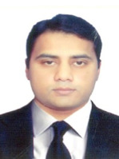

**Adnan Amin** received the MSc degree in Computer Science from University of Peshawar, MS degree (with Distinction) in Computer Science with major Databases from Institute of Management Sciences Peshawar, Pakistan in 2008 and 2015 respectively. He is currently a Ph.D Scholar and Lecturer at Department of Computing Sciences at Institute of Management Sciences Peshawar. His research interests include Data mining, Databases, Big Data and Machine Learning.

**Sajid Anwar** obtained his BSc (Comp. Sc) and MSc (Comp. Sc) degrees from University of Peshawar in 1997 and 1999 respectively. He obtained his MS (Comp. Sc) and PhD (in Software Architecture) from the University of NUCES-FAST, Pakistan, in 2007 and 2011 respectively. He is currently Assistant Professor of Computing Science, and coordinator of the BS-Software Engineering at the Institute of Management Sciences Peshawar, Pakistan. His research interests are concerned with Software Architecture, Software Requirement Engineering, Searched Based Software Engineering and Mining Software Repository.

**Awais adnan** is Assistant Professor and Cooerdinator of Master Program, Department of Comptuer Science in Institute of Management Sciences Peshawar. He has done his Ph.D. from IMSciences|Peshawar and MS from NUST Islamabad. He is manager of ORIC in IMSciences|Peshawar to promote and facilitate the research students in commercialization of their research. His major areas of interest are Multimedia and Machine Learning.

**Muhammad Nawaz** received his MSc (Computer Science) and MS in Information Technology from University of Peshawar-Pakistan. He worked as a lecturer at the University of Peshawar; followed by working as a Computer Programmer at Khyber Teaching Hospital, Peshawar; and then appointed as Assistant Professor in Multimedia at the Institute of Management Sciences, Peshawar - a position he still holds. Currently he is the Head of PhD and MS-Computer Sciences at the IMSciences | Peshawar.

**Khalid Alawfi** received the B.Sc degree in computer engineering in 1999 from King Fahd University of Petroleum and Minerals (KFUPM), Saudi Arabia, and MSc and PhD degrees in Informatics from Bradford University, UK, in 2002 and in 2006 respectively. During 2002–2006, he worked as part of the Networks and Performance Engineering Research Group at Bradford University. Currently he is an Associate Professor in Computer Science, and Dean of the College of Computer Science and Engineering at Taibah University in Saudi Arabia. He is also a Senior Honorary Fellow at the Cognitive Big Data Informatics (CogBID) Research Laboratory at the University of Stirling, Scotland, UK.

**Kaizhu Huang** is currently an Associate Professor in Xi’an Jiaotong-Liverpool University, China. Before that, he was an Associate Professor at National Laboratory of Pattern Recognition (NLPR), Institute of Automation, Chinese Academy of Sciences (CASIA). He was a student of the Special Class for Gifted Youth at Xi'an Jiaotong University and received the B.Sc. degree in Engineering in 1997. He received the M.Sc. degree in Engineering from CASIA in July 2000 and the Ph.D. degree from The Chinese Univ. of Hong Kong (CUHK) in 2004. He worked as a research scientist in Fujitsu R&D Centre from 2004 to 2007. During 2008 and 2009, he was a research fellow in CUHK and a researcher at University of Bristol, UK. He is the recipient of 2011 Asian Pacific Neural Network Assembly (APNNA) Distinguished Younger Researcher Award. He also received Best Book Award in National “Three 100“Competition 2009. He has published 6 books in Springer and over 110 international research papers (40 SCI-indexed international journals and 60+ EI conference papers) e.g., in journals (JMLR, Neural Computation, IEEE T-PAMI, IEEE T-NN, IEEE T-BME, IEEE T-SMC, NN) and conferences (NIPS, IJCAI, SIGIR, UAI,CIKM, ICDM, ICML,ECML, CVPR). He serves as Advisory Board Member in Springer Book Series Bio- Neuroinformatics. He is the member of CCF Technical Committee of Artificial Intelligence and Pattern Recognition. He served on the programme committees in many international conferences such as ICONIP, IJCNN, IWACI, EANN, KDIR. Especially, he serves as chairs in several major conferences or workshops, e.g., AAAI 2016 (Area Chair), ACML 2016 (Publication co-Chair), ICONIP 2014 (Program co-Chair), DMC 2012–2016 (Organizing co-Chair), ICDAR 2011 (Publication Chair), ACPR 2011 (Publicity Chair), ICONIP2006, 2009–2011 (Session Chair).

**Amir Hussain** received the BEng (with highest first class Hons.) and the Ph.D. degree in novel neural network architectures and algorithms from the University of Strathclyde, Glasgow, U.K., in 1992 and 1997, respectively. He is currently full Professor of Computing Science, and founding Director of the Cognitive Big Data Informatics (CogBID) Research Laboratory at the University of Stirling in Scotland, UK. He has conducted and led collaborative research with industry; partnered in major European and international research programs, and supervised over 30 Ph.D. students. He has (co)authored over 300 papers, including over a dozen books and 100+ journal papers. He is founding Editor-in-Chief of the journals: Cognitive Computation (Springer Nature), and Big Data Analytics (BioMed Central), and Chief-Editor of the Springer Book Series on Socio-Affective Computing, and Cognitive Computation Trends. He is Associate Editor of the IEEE Transactions on Neural Networks and Learning Systems, the IEEE Transactions on Systems, Man, and Cybernetics: Systems, and the IEEE Computational Intelligence Magazine. He is Chapter Chair of the IEEE UK & RI Industry Applications Society, Vice-Chair of the Emerging Technologies Technical Committee of the IEEE Computational Intelligence Soceity (CIS), and founding General Chair for the IEEE CIS sponsored, flagship IEEE SSCI (CICARE Symposium) series. He is a senior Fellow of the Brain Science Foundation (USA).

**<sup>1</sup>**

(“Data Source Link http://www.sgi.com/tech/mlc/db/”)

© 2016 Elsevier B.V. All rights reserved.

12

Citations

Captures

Social Media